# TEMA 06 - Teoría de Respuesta al Item (TRI)

02. Conceptos avanzados

Miguel A. Castellanos López

## TRI: Conceptos avanzados

[figure not shown]

# Fiabilidad en la TRI

- En la TCT la fiabilidad se expresa como $\rho_{XV}^{2}$
  $$\rho_{XV}^{2}=\frac{\sigma_{V}^{2}}{\sigma_{X}^{2}}=1-\frac{\sigma_{E}^{2}}{\sigma_{X}^{2}}$$
- Es un valor único para cualquier aplicación del test
- En la TRI la fiabilidad no es un número sino una función
- Se representa con la *Función de Información* ($I(\theta)$)

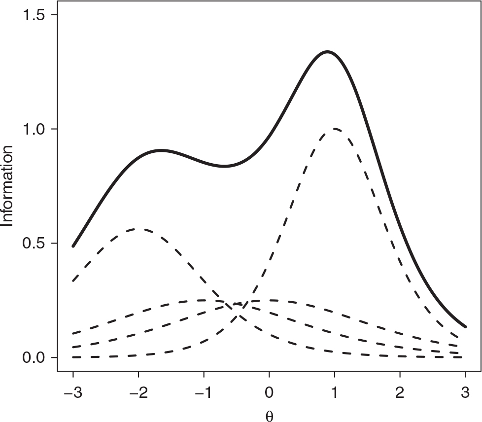

# Función de Información del item

- Una para cada ítem
- Se define como:

$$I_{i}(\theta)=\frac{P'_{i}(\theta)^{2}}{P_{i}(\theta)Q_{i}(\theta)}$$

- Donde $P'_{i}(\theta)$ es la derivada primera de la CCI para cada $\theta$
- Resolviendo esa derivada para cada uno de los tres modelos nos da lo siguiente:

### 1P

$$I_{i}(\theta)=D^{2}P_{i}(\theta)Q_{i}(\theta)$$

### 2P

$$I_{i}(\theta)=D^{2}a_{i}^{2}P_{i}(\theta)Q_{i}(\theta)$$

### 3P

$$I_{i}(\theta)=\frac{D^{2}a_{i}^{2}Q_{i}(\theta)[P_{i}(\theta)-c_{i}]^{2}}{(1-c_{i})^{2}P_{i}(\theta)}$$

# Punto de máxima información para el ítem

Cada ítem tendrá un punto en el que su función de Información sea máxima

### 1P

$$I_{max}(\theta)=b_{i}$$

### 2P

$$I_{max}(\theta)=b_{i}$$

### 3P

$$I_{max}(\theta)=b_{i}+\frac{1}{Da_{i}}ln (0.5 [1+\sqrt{1+8c_{i}}])$$

# Función de Información para el test

- Es la suma de las Funciones de Información de los items

$$I(\theta)=\sum_{i=1}^{n}I_{i}\theta$$

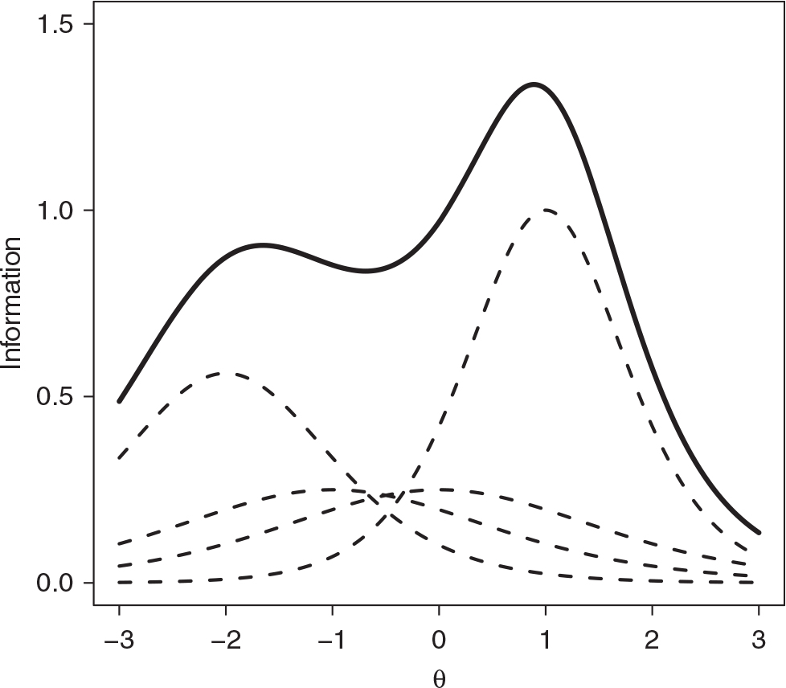

# Error Típico de Estimación del TEST

- Es la inversa de la Función de Información del Test
- Da la misma información

$$ET=\frac{1}{\sqrt{I(\theta)}}$$

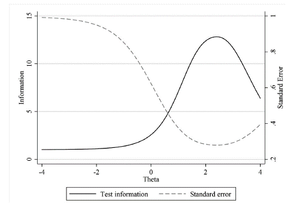

### CUIDADO: no confundir con el error típico de medida que se calcula para la V

## Estimación de Parámetros

[figure not shown]

- Hay dos grandes técnicas para hacerlo:
  - Máxima Verosimilitud
  - Bayes

# Máxima Verosimilitud

- Una moneda trucada con una probabilidad de obtener cara $p$ desconocida
- En un experimento he obtenido 70 caras de 100 intentos
- El objetivo es encontrar el valor $p$ que más probablemente haya generado ese resultado empírico (70 caras y 30 cruces)

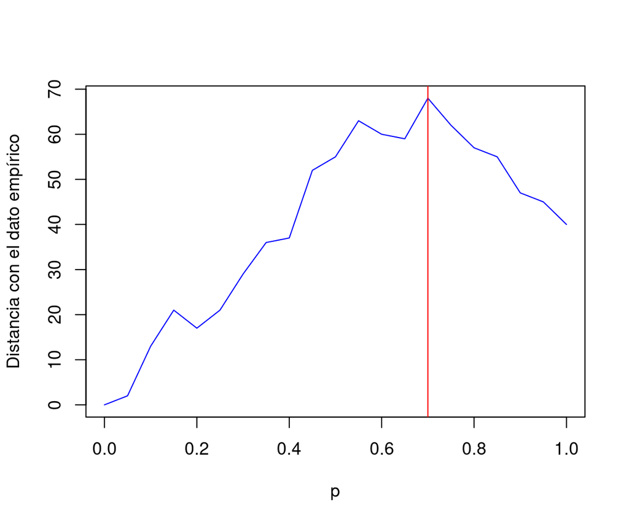

- Se puede concluir que $p=0.7$ porque es el valor más probable

# Máxima Verosimilitud

- Es un método Iterativo
- Es complejo de calcular
- Consiste en construir una función de verosimilitud ($L$) que relacione uno (o varios) parámetros con la probabilidad de obtener unos datos empíricos.
- En la TRI:
  - Los datos empíricos son las respuestas de los sujetos a los items
  - Los parámetros son las $\theta$ de los sujetos y los parámetros de los items (a, b y c)
- En la TRI hay varias funciones de verosimilitud dependiendo de la situación
- Solo vamos a ver una, la más sencilla

# Máxima Verosimilitud

### Tenemos las respuestas de los sujetos y queremos encontrar su $\theta$

- Tenemos el patrón ($U$) de respuesta del sujeto, $s$, en los $n$ items
- En ese caso la función de verosimilitud (L) viene dada por:

$$L(u_{1s}, u_{1s}, \dots, u_{ns}|\theta_{s})=\prod_{i=1}^{n}P_{i}(\theta_{s})^{u_{is}}Q_{i}(\theta_{s})^{1-u_{is}}$$

- $L$ relaciona los posibles valores de $\theta$ con el patrón de aciertos/fallos del sujeto ($u_{1s}, u_{1s}, \dots, u_{ns}$)
- Cuanto mayor sea L más probable es que ese valor de $\theta$ haya generado el patrón
- En este caso es obligatorio conocer los parámetros de los items para poder calcular las P y Q de los items
- Para encontrar el máximo se calcula la derivada

$$\frac{\partial L(U|\theta)}{\partial \theta_{s}}=0$$

- Se resuelve utilizando procedimientos iterativos como *Newton-Raphson*

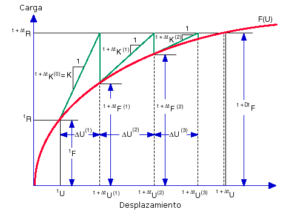

# Máxima Verosimilitud

Ejemplo: U=(1, 0, 0)
$$L(1, 0, 0|\theta)=P_{1}(\theta)^{1}Q_{1}(\theta)^{1-1} \cdot P_{2}(\theta)^{0}Q_{2}(\theta)^{1-0} \cdot P_{3}(\theta)^{0}Q_{3}(\theta)^{1-0}$$
$$L(1, 0, 0|\theta)=P_{1}(\theta) \cdot Q_{2}(\theta) \cdot Q_{3}(\theta)$$

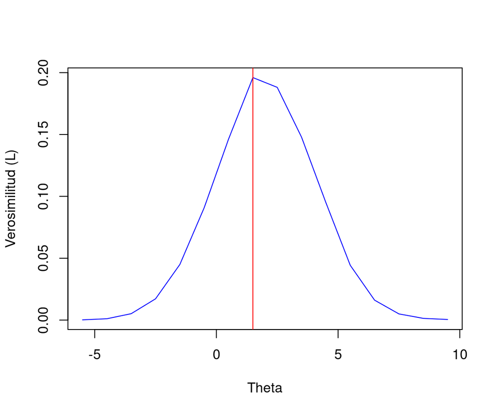

# Estimación Condicional y Estimación Conjunta

### Estimación Condicional

- Acabamos de verla
- Conoces los parámetros de los items $\Rightarrow$ estimas las $\theta$ de los sujetos
- Se usa cuando está *“calibrado”* el test

### Estimación Conjunta

- No conoces nada, es la *“calibración”* del test
- Estimas todo a la vez (las $\theta$ y los parámetros)
- No existe una solución única, infinitas soluciones son igualmente válidas
- *NO EXISTE UNA MÉTRICA ÚNICA para $\theta$*

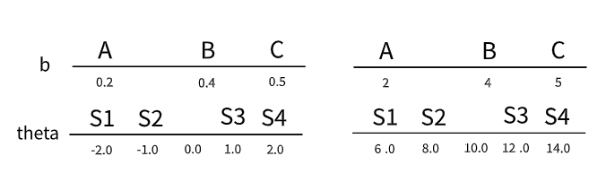

### Las relaciones Sí se mantienen (*intervalo*)

# Estimación Condicional y Estimación Conjunta

- *Estrictamente NO se cumple la invarianza de parámetros y de sujetos*
- Soluciones:
  - Transformación a una escala común
  - Ahormamiento bayesiano
  - Anclaje de items

# Transformaciones de las puntuaciones

- Ayudan a la interpretación de las puntuaciones
- Siendo M y S dos valores “*arbitrarios*”

$$1P: \theta' = M + \theta \Rightarrow \left\{\begin{matrix} b' = M + b \end{matrix}\right.$$

$$2P: \theta' = M + S \theta \Rightarrow \left\{\begin{matrix}a' = \frac{a}{S}
\\ b' = M + Sb \end{matrix}\right.$$

$$3P: \theta' = M + S \theta \Rightarrow \left\{\begin{matrix}a' = \frac{a}{S}
\\ b' = M + Sb
\\ c' = c \end{matrix}\right.$$

Lo interesante es acabar en una escala “cómoda” como la [100,15], T, etc.  
Para ello:

1. Conseguimos que $\theta$ esté en una escala 0, 1
   - Ahormamiento, tipificación, etc.
2. Elegimos M y S que deseemos (los de la escala final)
3. Transformamos los valores de $\theta$, a, b y c

Otras transformaciones habituales: logits y wits

# Ajuste del modelo

Se comprueba cómo el modelo predice resultados que coinciden con los datos empíricos que tenemos

- Hay muchos procedimientos
- Un análisis para cada ítem
- Hay que partir $\theta$ en intervalos

### Basados en $\chi^{2}$

$$Q_{1}=\sum_{j=1}^{k}\frac{n_{j}[P(\theta_{j})-P_{e}(\theta_{j})]^{2}}{P(\theta_{j})[1-P(\theta_{j})]} \Rightarrow \chi^{2}_{(k-p)}$$

- $n_{j}$ frecuencia de casos en la categoría j
- $P_{e}(\theta_{j})$ proporción de aciertos empíricos
- $P(\theta_{j})$ proporción de aciertos predicho por el modelo

### Basados en los Residuos Estandarizados (RE)

$$RE = \frac{P(\theta_{j})-P_{e}(\theta_{j})}{\sqrt{\frac{P(\theta_{j})Q(\theta_{j})}{n_{j}}}}$$

- Cuanto más se alejen del 0 mayor diferencia
- Valores entre -2 y +2 son razonables

# Ejercicio

Sabiendo que el ítem ha sido ajustado con el modelo de Rasch (b=2). Calcular el ajuste por el método de $\chi^{2}$ y de los Residuos Estandarizados

| $\theta$ | $n_{j}$ | $P_{e}(\theta_{j})$ | $P(\theta_{j})$ |
| --- | --- | --- | --- |
| (4-5] | 70 | 0.97 |  |
| (3-4] | 90 | 0.95 |  |
| (2-3] | 200 | 0.70 |  |
| (1-2] | 300 | 0.35 |  |
| (0-1] | 340 | 0.10 |  |

# Aplicaciones de la TRI

### Estudiar la Eficiencia Relativa de dos test

$$ER(X,Y,\theta)=\frac{I_{X}(\theta)}{I_{Y}(\theta)}$$

- 1: Igualmente informativos
- en el rango [1, $+\infty$]: X es más informativo
- en el rango [0,1]: Y es más informativo

### Crear Bancos de Items

Podemos elegir items que maximicen algún criterio, pe:

- Mínimos items para ser máximamente informativo
- Test máximamente informativo en puntuaciones altas (altas capacidades)
- Etc.

# Aplicaciones de la TRI

### Estudio del DIF

Se ajusta una CCI para cada grupo

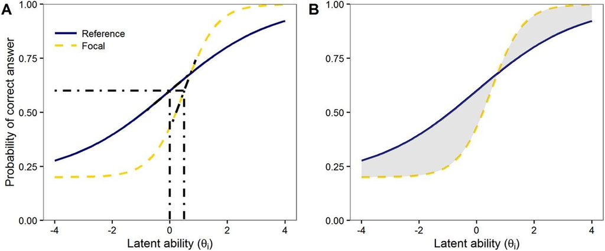

- Comparación de parámetros
- Área de diferencia entre las dos CCI

### Test Adaptativos Informatizados

- En desarrollo

# Comparación entre la TCT y la TRI

|  | TCT | TRI |
| --- | --- | --- |
| Modelo | Lineal | No lineal |
| Supuestos | Débiles | Fuertes |
| Invarianza de las propiedades de los sujetos | No | Sí |
| Invarianza de las propiedades del test | No | Sí |
| Escala de puntuaciones | 0 y $n_{i}$ | $-\infty$ y $+\infty$ |
| Énfasis | Test | Items |
| Relación ítem-rasgo | Sin especificar | CCI |
| Descripción de los items | ID y $\rho_{iX}$ | Parámetros a, b y c |
| Fiabilidad | $\rho_{XV}^{2}$ | Función de Información |
| Tamaño muestral | entre 200 y 500 | +500, dependiendo del modelo |

# Modelos avanzados en la TRI

- Infinidad de nuevos modelos
- Muy avanzados e interesantes
- Muy poco usados en la práctica

### Modelos de respuesta politómicos

- Modelo de Respuesta Graduada de Samejima
- Modelo de *Rating Scale* de Muraki
- Modelo de Crédito Parcial

### Modelos multidimensionales

- LLTM
- Mirt

### Modelos de Clase Latente

### Modelos no compensatorios